# Regresión por Componentes Principales (PCR)

Luis Lefevre y Manuel Medina

3 de Diciembre de 2022

```r
# Carga de librerías
library(tidyverse)
library(tidymodels)
library(gridExtra)
library(GGally)
library(pls)
```

Desarrollaremos un modelo de Regresión por componentes principales para la predicción de los salarios de jugadores de la NBA en la temporada 2022-2023 en base a información de la temporada pasada y lo compararemos con un modelo lineal múltiple.

*Para la construcción de este script se tomó como guía el código desarrollado para la aplicación de PCR en el libro: An Introduction to Statistical Learning (Página 279) y el código proporcionado por Juan Manuel Barriola, Azul Villanueva y Franco Matelli en su clase práctica sobre [Regularización: Lasso, Ridge y Elastic Net](https://github.com/eea-uba/EEA-2022/tree/main/clase%2010).

# Dataset

El dataset al que se aplicará PCR fue tomado de la clase práctica sobre [Regularización: Lasso, Ridge y Elastic Net](https://github.com/eea-uba/EEA-2022/tree/main/clase%2010) de Juan Manuel Barriola, Azul Villanueva y Franco Matelli, ellos fueron los que se encargaron de la recopilación y limpieza de los datos.

El dataset consiste en estadísticas por partido de jugadores de la NBA durante la temporada 2021-2022 y sus salarios de la temporada 2022-2023 provenientes de la página [Basketball Reference](https://www.basketball-reference.com)

Los scripts para la creación del dataset son estos: [creacion_dataset_nba](https://github.com/eea-uba/EEA-2022/blob/main/clase%2010/creacion_datasets_nba.Rmd) y [build_df](https://github.com/eea-uba/EEA-2022/blob/main/clase%2010/build_df.Rmd)

Variables del dataset y breve descripción:

```r
diccionario = read_csv("diccionario_terminos.csv")
diccionario
```

| variable | descripcion |
| --- | --- |
| Player | nombre |
| Pos | Posición |
| Age | Edad |
| G | Partidos |
| GS | Partidos que comenzó como titular |
| MP | Minutos jugados |
| PTS | Points |
| FG | Field Goals |
| FGA | Field Goal Attempts |
| FG% | Field Goal Percentage |

[output cut: 38 more lines]

Datos de salarios y estadísticas por jugador para la temporada 2022-2023

```r
# Los datos de salario son para la temporada 2022-2023
nba = read_csv("nba_player_stats_salary_2022_2023.csv")
# Vemos las dimensiones del dataset
dim(nba)
```

```
## [1] 404  50
```

```r
# Verificamos si existen filas con NA en la variable salario
sum(is.na(nba$salario))
```

```
## [1] 2
```

```r
# Removemos todas las filas que tengan algún registro con NA
nba <- na.omit(nba)
# Vemos nuevamente las dimensiones
dim(nba)
```

```
## [1] 402  50
```

```r
# Vemos algunos registros
glimpse(nba)
```

```
## Rows: 402
## Columns: 50
## $ jugador <chr> "Precious Achiuwa", "Steven Adams", "Bam Adebayo", "Santi Alda…
## $ Pos     <chr> "C", "C", "C", "PF", "SG", "SG", "C", "PG", "PF", "PF", "SF", …
## $ Age     <dbl> 22, 28, 24, 21, 23, 26, 23, 23, 28, 27, 29, 21, 24, 34, 21, 23…
## $ Tm      <chr> "TOR", "MEM", "MIA", "MEM", "TOT", "MIL", "CLE", "NOP", "MEM",…
## $ G       <dbl> 73, 76, 56, 32, 65, 66, 56, 54, 69, 67, 48, 65, 48, 55, 82, 58…
## $ GS      <dbl> 28, 75, 56, 0, 21, 61, 56, 1, 11, 67, 6, 65, 48, 2, 8, 58, 6, …
## $ MP      <dbl> 1725, 1999, 1825, 360, 1466, 1805, 1809, 834, 1484, 2204, 473,…
## $ FG      <dbl> 265, 210, 406, 53, 253, 255, 369, 131, 209, 689, 70, 357, 309,…
## $ FGA     <dbl> 603, 384, 729, 132, 680, 569, 545, 294, 469, 1245, 128, 912, 6…
## $ `FG%`   <dbl> 0.439, 0.547, 0.557, 0.402, 0.372, 0.448, 0.677, 0.446, 0.446,…
## $ `3P`    <dbl> 56, 0, 0, 6, 105, 159, 1, 32, 36, 71, 2, 132, 115, 68, 82, 7, …
## $ `3PA`   <dbl> 156, 1, 6, 48, 338, 389, 10, 110, 109, 242, 14, 391, 317, 164,…
## $ `3P%`   <dbl> 0.359, 0.000, 0.000, 0.125, 0.311, 0.409, 0.100, 0.291, 0.330,…
```

[output cut: 37 more lines]

## Análisis Exploratorio

Existen 5 posiciones en el basket, a continuación una breve descripción de cada una:

- **Point Guard (PG)**: conocido como base, se caracteriza por su habilidad para pasar y manejar la pelota y organizar las jugadas. Suelen ser personas de baja estatura en el equipo.
- **Shooting Guard (SG)**: conocido como escolta, se caracteriza por su habilidad para anotar de larga y media distancia. También suelen tener buenas habilidades de manejo y pase de la pelota.
- **Small Forward (SF)**: conocido como alero, se la considera la posición más versátil de todas. Se caracterizan por su capacidad de anotar puntos de maneras distintas (triples, tiros a distancia media y corta) y su capacidad atlética.
- **Power Forward (PF)**: conocido como ala pivot, se caracteriza por anotar desde un rango medio a corto y la defensa próxima al aro. Suelen ser jugadores altos pero con mayor flexibilidad que los pivots.
- **Center (C)**: conocido como pivot, se caracteriza por ser jugadores muy altos y jugar cerca del aro, motivo por el cual se destacan en en las anotaciones de 2 puntos, la toma de rebotes y bloqueos.

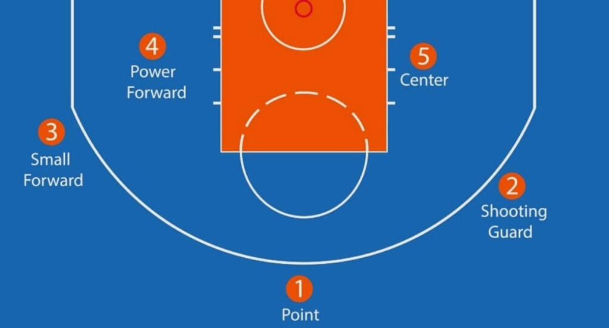

Fuente: www.chaseyoursport.com

## Correlograma

Realizamos un correlograma entre las variables cuantitativas.

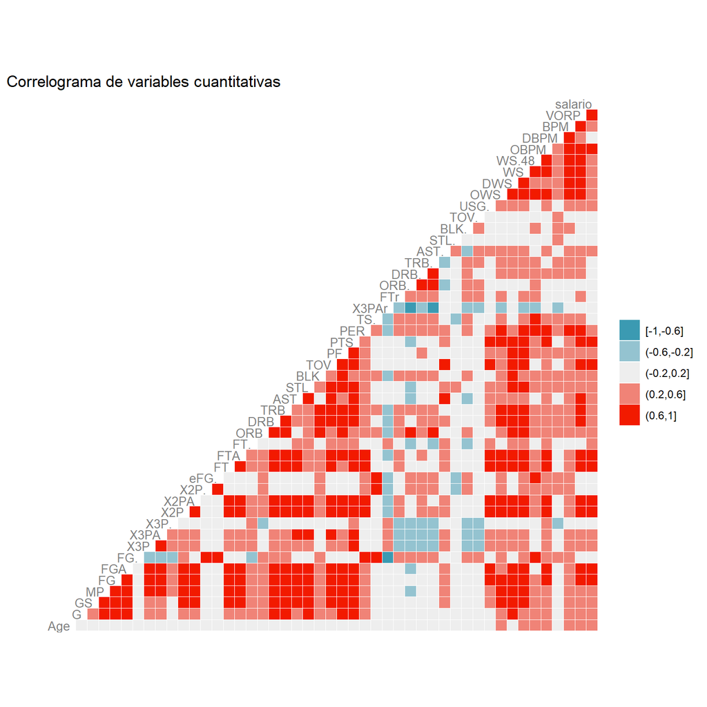

```r
nba %>%
  select_if(is.numeric) %>% # selección variables numéricas
  ggcorr(., layout.exp = 5, hjust = 1, size = 3.5, nbreaks = 5, color = "grey50") + # graficamos correlacion pearson
  labs(title='Correlograma de variables cuantitativas')
```

¿Qué podemos observar?

- El salario tiene un correlación positiva con la gran mayoría de las demás variables. Por ejemplo entre con las variables: puntos (PTS), intentos de anotaciones de campo (FGA), anotaciones de 2 puntos (X2P).
- Existe una cantidad considerable de variables que tienen una correlación fuerte con otras. Por ejemplo entre: puntos (PTS) y personal fouls (PF) o tiros libres (FT) y intentos de tiros libres (FTA)

Observemos las relaciones entre algunas variables usando `ggpairs`.

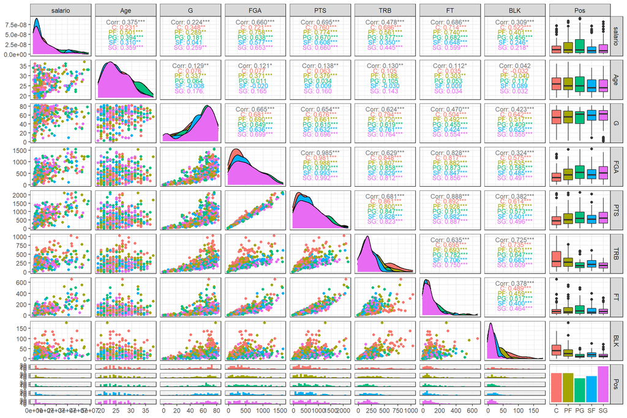

```r
nba %>%
  select(salario, Age, G, FGA, PTS, TRB, FT, BLK, Pos) %>%
  ggpairs(aes(color = Pos), upper = list(continuous = wrap("cor", size = 3, hjust=0.5)), progress=FALSE) +
  theme(axis.text.x = element_text(angle = 90, hjust = 1), legend.position = "bottom") +
  theme_bw()
```

¿Qué podemos observar?

- Todas las variables elegidas tienen una correlación positiva con la variable salario, siendo la que tiene la mayor correlación el número de puntos anotados (PTS) 0.695.
- Dependiendo de la posición existe más o menos varianza entre los salarios.
- En cada posición existen outliers con respecto al salario.
- Entre la gran mayoría de las variables numéricas también existe una correlación positiva.
- Las variables que tienen la mayor correlación son: el número de anotaciones (PTS) e intentos de anotaciones de campo (FGA), con 0.985; seguida de PTS y tiros libres (FT) con 0.888

¿Por qué elegimos este dataset para PCR?

- El número de registros no es tan grande comparado con el número de variables, tenemos 402 registros con 48 variables.
- Tenemos muchas variables que están fuertemente correlacionadas con otras. Podemos obtener un subconjunto de componentes principales que capturen la mayoría de la varianza de las variables predictoras y su relación con la respuesta, el salario.

# Modelo Lineal Múltiple

$salario = \beta_0 +\beta_1X_1+\beta_2X_2+...+\epsilon$

Recordemos que en el modelo lineal múltiple estimamos coeficientes para cada variable del dataset, además del intercept.

Primero probaremos el uso de un modelo lineal múltiple que use todas las variables, exceptuando: jugador y equipo, quedandonos con 47 variables.

```r
# Eliminamos las variables jugador  y equipo (Tm)
nba <- nba %>% select(-c(jugador, Tm))
# Reescalamos las variables numericas
nba_scaled <- nba %>% mutate_at(vars(-Pos), scale)
# Nuevo modelo lineal
modelo_lineal <- lm(formula = salario~., data = nba_scaled)
summary(modelo_lineal)
```

```
##
## Call:
## lm(formula = salario ~ ., data = nba_scaled)
##
## Residuals:
##      Min       1Q   Median       3Q      Max
## -1.61874 -0.30087 -0.01361  0.27662  2.06034
##
## Coefficients: (4 not defined because of singularities)
##              Estimate Std. Error t value Pr(>|t|)
## (Intercept) -0.055783   0.097525  -0.572  0.56770
## PosPF        0.071274   0.106819   0.667  0.50505
## PosPG       -0.013040   0.170159  -0.077  0.93896
## PosSF        0.157994   0.129209   1.223  0.22222
## PosSG        0.059914   0.136932   0.438  0.66198
## Age          0.267890   0.031623   8.471 6.53e-16 ***
## G           -0.415324   0.076899  -5.401 1.22e-07 ***
## GS           0.124109   0.067145   1.848  0.06538 .
## MP          -0.180328   0.260504  -0.692  0.48925
## FG           0.725374   0.959524   0.756  0.45017
## FGA         -0.543620   1.055310  -0.515  0.60678
## `FG%`        0.467422   0.504056   0.927  0.35439
## `3P`        -0.177973   0.378545  -0.470  0.63854
## `3PA`        0.448504   0.382624   1.172  0.24191
## `3P%`       -0.068896   0.043055  -1.600  0.11045
## `2P`               NA         NA      NA       NA
## `2PA`              NA         NA      NA       NA
## `2P%`       -0.018308   0.069276  -0.264  0.79172
## `eFG%`      -0.273366   0.478860  -0.571  0.56845
## FT          -0.114480   0.456820  -0.251  0.80227
## FTA          0.375893   0.353196   1.064  0.28793
## `FT%`        0.039561   0.047397   0.835  0.40446
## ORB         -0.054543   0.130912  -0.417  0.67720
## DRB         -0.059303   0.140581  -0.422  0.67339
## TRB                NA         NA      NA       NA
## AST          0.194840   0.235796   0.826  0.40918
## STL         -0.080459   0.099328  -0.810  0.41847
## BLK          0.247055   0.078626   3.142  0.00182 **
## TOV         -0.092880   0.270586  -0.343  0.73161
## PF          -0.015964   0.082492  -0.194  0.84666
```

[output cut: 12 more lines]

```
## `USG%`       0.164412   0.165204   0.995  0.32031
## OWS         -0.229953   0.986025  -0.233  0.81573
## DWS          0.035747   0.540796   0.066  0.94733
## WS           0.488555   1.397428   0.350  0.72684
## `WS/48`     -0.131053   0.221194  -0.592  0.55390
## OBPM        -1.827725   1.565168  -1.168  0.24369
## DBPM        -1.234486   0.847326  -1.457  0.14602
## BPM          2.949331   1.947706   1.514  0.13085
## VORP        -0.179908   0.197830  -0.909  0.36375
## ---
## Signif. codes:  0 '***' 0.001 '**' 0.01 '*' 0.05 '.' 0.1 ' ' 1
##
## Residual standard error: 0.546 on 355 degrees of freedom
## Multiple R-squared:  0.7361, Adjusted R-squared:  0.7019
## F-statistic: 21.53 on 46 and 355 DF,  p-value: < 2.2e-16
```

Mostramos graficamente los coeficientes estimados y sus intervalos de confianza.

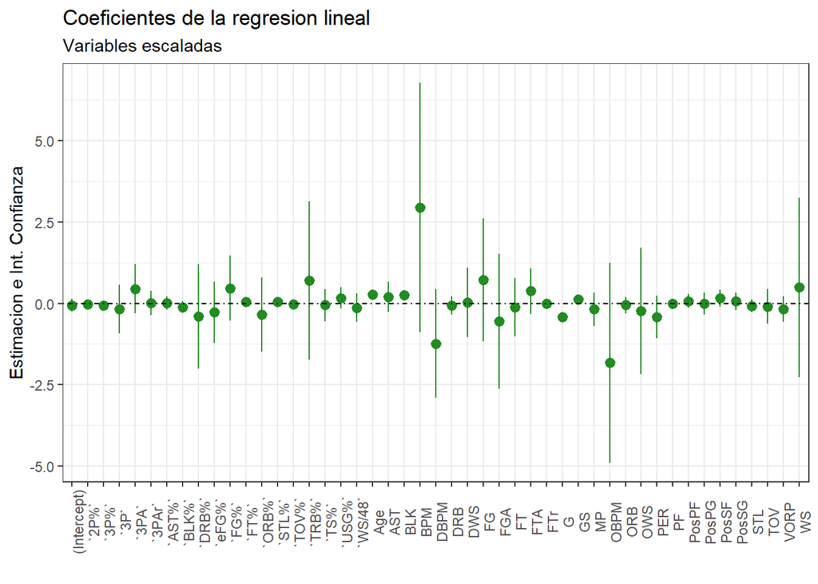

```r
lineal_coef = modelo_lineal %>% tidy(conf.int=TRUE)

lineal_coef %>% filter(!is.na(estimate)) %>%
  ggplot(., aes(term, estimate))+
  geom_point()+
  geom_pointrange(aes(ymin = conf.low, ymax = conf.high), color = "forestgreen")+
  geom_hline(yintercept = 0, lty = 4, color = "black") +
  labs(title = "Coeficientes de la regresion lineal", subtitle="Variables escaladas", x="", y="Estimacion e Int. Confianza") +
  theme_bw() +
  theme(axis.text.x = element_text(angle=90))
```

Graficamos los p-valores de mayor a menor para evaluar la significatividad de los coeficientes.

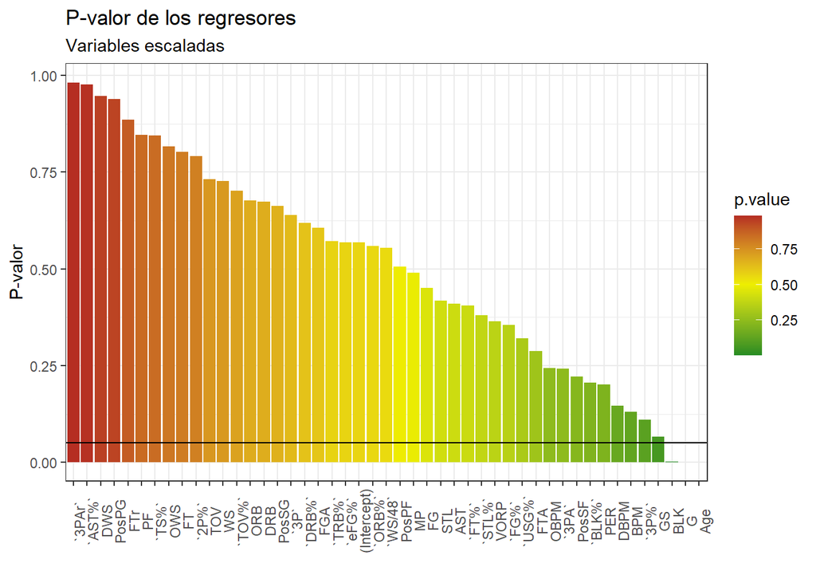

```r
lineal_coef %>% filter(!is.na(estimate)) %>%
  ggplot(., aes(reorder(term, -p.value), p.value, fill=p.value))+
  geom_bar(stat = 'identity', aes(fill=p.value))+
  geom_hline(yintercept = 0.05) +
  labs(title = "P-valor de los regresores",subtitle="Variables escaladas", x="", y="P-valor") +
  theme_bw() +
  theme(axis.text.x = element_text(angle=90)) +
  scale_fill_gradient2(high='firebrick', low = 'forestgreen', mid='yellow2',midpoint = 0.5 )
```

¿Qué podemos observar?

- Solo 3 variables tienen coeficientes significativos: BLK, G y Age.
- 4 variables tienen coeficientes estimados con NA: 2P, 2PA, PTS y TRB
- La alta cantidad de variables y el hecho que algunas tengan una alta correlación ocasiona que los coeficientes estimados tengan alta varianza y por lo tanto no sean significativos.
- PCR puede ayudarnos al reducir el número de coeficientes a estimar.

# PCR

```r
#seteamos la semilla para la replicabilidad de los resultados
set.seed(123)
#aplicamos PCR usando la función pcr de la librería pls
modelo_pcr <- pcr(salario ~ ., data = nba_scaled, scale = FALSE, validation = "CV")
summary(modelo_pcr)
```

```
## Data:    X dimension: 402 50
##  Y dimension: 402 1
## Fit method: svdpc
## Number of components considered: 50
##
## VALIDATION: RMSEP
## Cross-validated using 10 random segments.
##        (Intercept)  1 comps  2 comps  3 comps  4 comps  5 comps  6 comps
## CV           1.001   0.7279   0.7193   0.7181   0.6710   0.6723   0.6586
## adjCV        1.001   0.7277   0.7191   0.7180   0.6701   0.6719   0.6573
##        7 comps  8 comps  9 comps  10 comps  11 comps  12 comps  13 comps
## CV      0.6546   0.6544   0.6311    0.6107    0.6018    0.6047    0.6053
## adjCV   0.6551   0.6543   0.6316    0.6086    0.6008    0.6033    0.6041
##        14 comps  15 comps  16 comps  17 comps  18 comps  19 comps  20 comps
## CV       0.6071    0.5702    0.5668    0.5667    0.5705    0.5729    0.5725
## adjCV    0.6063    0.5665    0.5649    0.5650    0.5687    0.5711    0.5704
##        21 comps  22 comps  23 comps  24 comps  25 comps  26 comps  27 comps
## CV       0.5738    0.5744    0.5758    0.5780    0.5781    0.5792    0.5799
## adjCV    0.5717    0.5723    0.5738    0.5757    0.5754    0.5764    0.5770
##        28 comps  29 comps  30 comps  31 comps  32 comps  33 comps  34 comps
## CV       0.5817    0.5823    0.5822    0.5846    0.5925    0.5814    0.5853
## adjCV    0.5787    0.5798    0.5793    0.5818    0.5894    0.5779    0.5817
##        35 comps  36 comps  37 comps  38 comps  39 comps  40 comps  41 comps
## CV       0.5869    0.5902    0.5891    0.5964    0.6047    0.6091    0.6073
## adjCV    0.5833    0.5864    0.5853    0.5918    0.5996    0.6038    0.6019
##        42 comps  43 comps  44 comps  45 comps  46 comps  47 comps  48 comps
## CV       0.6125    0.6229    0.6231    0.6263    0.6290    0.6300    0.6170
## adjCV    0.6066    0.6162    0.6164    0.6194    0.6218    0.6221    0.6064
##        49 comps  50 comps
## CV       0.6172    0.6437
## adjCV    0.6027    0.5995
##
## TRAINING: % variance explained
##          1 comps  2 comps  3 comps  4 comps  5 comps  6 comps  7 comps  8 comps
## X          40.34    58.42    65.51    71.16    75.94    79.35    81.87    84.12
## salario    47.30    48.83    49.02    55.78    55.79    57.90    58.60    59.15
##          9 comps  10 comps  11 comps  12 comps  13 comps  14 comps  15 comps
## X          86.17     87.84     89.36     90.73     91.98     93.08     93.94
## salario    61.56     64.00     65.06     65.79     66.88     66.94     70.83
##          16 comps  17 comps  18 comps  19 comps  20 comps  21 comps  22 comps
## X           94.72     95.37     95.93     96.42     96.87     97.28     97.67
## salario     70.85     70.90     70.91     70.94     71.16     71.16     71.18
##          23 comps  24 comps  25 comps  26 comps  27 comps  28 comps  29 comps
## X           98.01     98.34     98.60     98.83     99.04     99.24     99.40
## salario     71.19     71.33     71.55     71.66     71.70     71.70     71.71
##          30 comps  31 comps  32 comps  33 comps  34 comps  35 comps  36 comps
## X           99.53     99.63     99.73     99.80     99.86     99.90     99.93
## salario     71.89     71.89     71.93     72.72     72.72     72.75     72.84
##          37 comps  38 comps  39 comps  40 comps  41 comps  42 comps  43 comps
## X           99.95     99.96     99.98     99.99     99.99    100.00    100.00
## salario     72.98     73.15     73.20     73.21     73.40     73.41     73.44
##          44 comps  45 comps  46 comps  47 comps  48 comps  49 comps  50 comps
## X          100.00    100.00    100.00    100.00    100.00    100.00    100.00
## salario     73.47     73.47     73.61     73.64     73.66     73.66     73.89
```

¿Qué podemos observar?

- Para cada componente se muestra el RMSE
- Las 2 primeras componentes explican el 58.42% de la varianza en los datos
- Con las primeras 27 componentes ya se explica el 99% de la varianza de los datos

Graficamos el MSE de CV para cada número de componentes

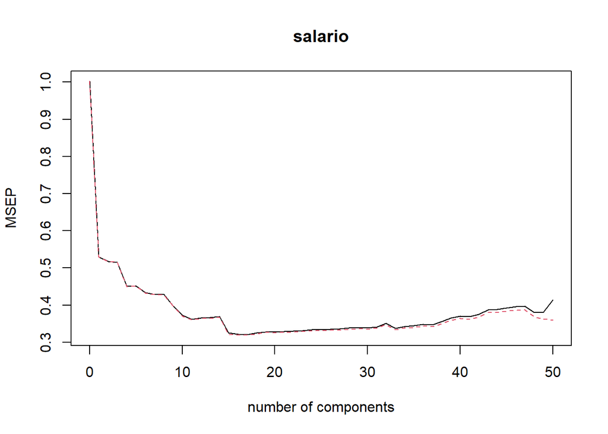

```r
validationplot(modelo_pcr, val.type = "MSEP")
```

El número de componentes con el que se obtiene un menor MSE es 17.

Las primeras 17 componentes explican alrededor del 95% de la varianza en los predictores y al rededor del 70% de la relación con la variable respuesta: salario.

# Evaluación de modelos

Para evaluar los modelos primero dividimos nuestro dataset en train y test

```r
set.seed(123)
train_test <- nba_scaled %>% initial_split(prop = 0.5)
train <- training(train_test)
test <- testing(train_test)
```

Entrenamos el modelo lineal múltiple con los datos de entrenamiento

```r
modelo_lineal_train <- lm(formula = salario ~ ., data = train)
#summary(modelo_lineal_train)
```

Predecimos sobre los datos de test

```r
lineal_pred <- predict(modelo_lineal_train, newdata = test)
mean((lineal_pred - test$salario[,1]) ^ 2) ^ 0.5
```

```
## [1] 0.7130786
```

Entrenamos el modelo usando PCR con los datos de entrenamiento y visualizamos los errores de CV

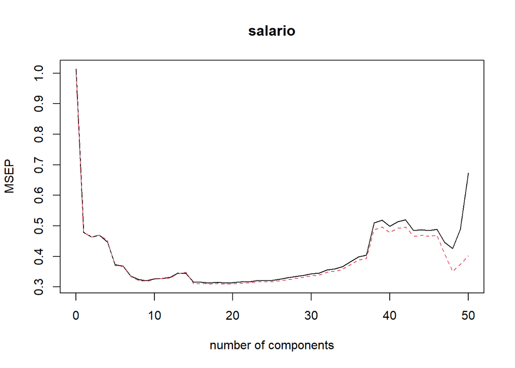

```r
set.seed(123)
modelo_pcr_train <- pcr(salario ~ ., data = train, scale = FALSE, validation = "CV" )
validationplot(modelo_pcr_train, val.type = "MSEP")
```

Vemos el summary para elegir el mejor número de componentes principales a usar

```r
summary(modelo_pcr_train)
```

```
## Data:    X dimension: 201 50
##  Y dimension: 201 1
## Fit method: svdpc
## Number of components considered: 50
##
## VALIDATION: RMSEP
## Cross-validated using 10 random segments.
##        (Intercept)  1 comps  2 comps  3 comps  4 comps  5 comps  6 comps
## CV           1.007   0.6918   0.6812   0.6855   0.6684   0.6112   0.6066
## adjCV        1.007   0.6914   0.6806   0.6857   0.6729   0.6085   0.6060
##        7 comps  8 comps  9 comps  10 comps  11 comps  12 comps  13 comps
## CV      0.5788   0.5690   0.5661    0.5720    0.5722    0.5761    0.5876
## adjCV   0.5785   0.5669   0.5635    0.5702    0.5713    0.5735    0.5854
##        14 comps  15 comps  16 comps  17 comps  18 comps  19 comps  20 comps
## CV       0.5868    0.5611    0.5619    0.5596    0.5620    0.5590    0.5601
## adjCV    0.5894    0.5570    0.5585    0.5559    0.5583    0.5557    0.5566
##        21 comps  22 comps  23 comps  24 comps  25 comps  26 comps  27 comps
## CV       0.5622    0.5621    0.5660    0.5657    0.5668    0.5706    0.5746
## adjCV    0.5586    0.5587    0.5632    0.5626    0.5623    0.5660    0.5696
##        28 comps  29 comps  30 comps  31 comps  32 comps  33 comps  34 comps
## CV       0.5776    0.5812    0.5854    0.5882    0.5967    0.5995    0.6052
## adjCV    0.5724    0.5758    0.5799    0.5824    0.5904    0.5930    0.5983
##        35 comps  36 comps  37 comps  38 comps  39 comps  40 comps  41 comps
## CV       0.6186    0.6311    0.6361    0.7141    0.7204    0.7065    0.7171
## adjCV    0.6111    0.6228    0.6272    0.6984    0.7044    0.6919    0.7016
##        42 comps  43 comps  44 comps  45 comps  46 comps  47 comps  48 comps
## CV       0.7210    0.6963    0.6985    0.6964    0.6992     0.668    0.6530
## adjCV    0.7043    0.6823    0.6844    0.6824    0.6851     0.639    0.5919
##        49 comps  50 comps
## CV       0.6990    0.8206
## adjCV    0.6118    0.6339
##
## TRAINING: % variance explained
##          1 comps  2 comps  3 comps  4 comps  5 comps  6 comps  7 comps  8 comps
## X          41.23    58.80    65.56    71.19    76.50    80.41    83.31    85.84
## salario    53.31    55.06    55.13    57.17    66.51    67.09    68.85    71.21
##          9 comps  10 comps  11 comps  12 comps  13 comps  14 comps  15 comps
## X          87.55     89.07     90.48     91.76     92.81     93.77     94.64
## salario    71.47     71.48     71.58     72.29     72.48     72.49     74.82
##          16 comps  17 comps  18 comps  19 comps  20 comps  21 comps  22 comps
## X           95.35      96.0     96.55     97.03     97.42     97.79     98.12
## salario     74.85      75.2     75.20     75.21     75.28     75.28     75.28
##          23 comps  24 comps  25 comps  26 comps  27 comps  28 comps  29 comps
## X           98.43     98.73     98.97     99.18     99.35     99.49     99.60
## salario     75.28     75.52     76.12     76.32     76.40     76.46     76.47
##          30 comps  31 comps  32 comps  33 comps  34 comps  35 comps  36 comps
## X           99.69     99.76     99.82     99.86     99.90     99.92     99.95
## salario     76.52     76.59     76.64     76.68     76.78     76.79     76.79
##          37 comps  38 comps  39 comps  40 comps  41 comps  42 comps  43 comps
## X           99.97     99.98     99.98     99.99    100.00    100.00    100.00
## salario     77.13     77.68     77.74     77.75     77.82     78.36     78.37
##          44 comps  45 comps  46 comps  47 comps  48 comps  49 comps  50 comps
## X          100.00     100.0     100.0     100.0    100.00    100.00    100.00
## salario     78.37      78.5      78.6      78.8     79.13     79.65     80.24
```

Hacemos la predicción usando el modelo entrenado previamente y especificando que el número de componentes a usar será 19, el que obtuvo un menor error.

```r
pcr_pred <- predict(modelo_pcr_train, test, ncomp = 19)
#Calculamos RMSE
mean((pcr_pred - test$salario[,1]) ^ 2) ^ 0.5
```

```
## [1] 0.6267468
```

**Podemos observar que usando el modelo con PCR se redujo el RMSE a 0.63, comparado con el valor obtenido con el modelo lineal múltiple que obtuvo un valor de 0.71**

Conclusiones

- PCR performará bien en casos donde las primeras componentes principales son suficientes para capturar la mayoría de la varianza en los predictores y a la vez la relación con la respuesta.
- Aunque PCR provee una forma simple de hacer regresión usando M < p predictores, no es un método de selección de features. Esto es porque cada una de las M componentes principales usadas en la regresión son una combinación lineal de todas las p features originales.
- En casos donde n >> p no se cumple, al reducir los coeficientes estimados, podemos reducir sustancialmente la varianza al costo de un incremento en el bias. Esto puede llevar a mejoras en el accuracy al predecir observaciones no usadas en el entranamiento.